# SQL-NoSQL analysis

```r
#This gives the counts of each category in each 'axis' specified

#Chi-squared test
chi_sq_test<-chisq.test(sex_conting)
chi_sq_test
```

```
##
##  Pearson's Chi-squared test with Yates' continuity correction
##
## data:  sex_conting
## X-squared = 47.709, df = 1, p-value = 4.945e-12
```

```r
#round(chi_sq_test$expected,2)

#To determine the nature of the dependence between rows (education) and columns (payment status), use chi-sq residuals (Pearson residuals)
chisq_resid<-round(chi_sq_test$residuals,3)
chisq_resid
```

```
##
##               0      1
##   female  2.049 -3.845
##   male   -2.529  4.746
```

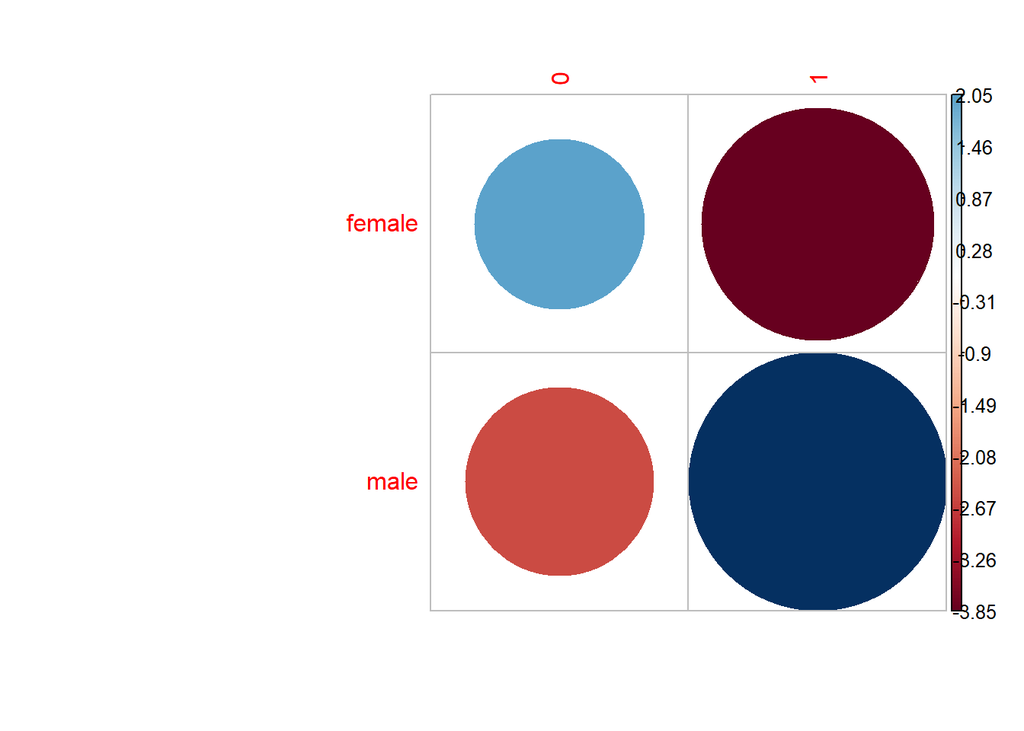

```r
#Visualization of the residuals shows the positive (blue) and negative (red) correlations between the row and column variables.
corrplot(chisq_resid, is.cor=FALSE)
```

Visualization of bill amount due vs. payment status

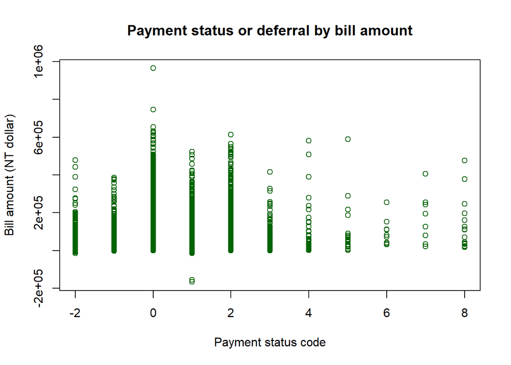

```r
plot(credit$PAY_1, credit$BILL_AMT1, main='Payment status or deferral by bill amount', xlab='Payment status code', ylab='Bill amount (NT dollar)', col='darkgreen')
```

Visualization of bill amount due vs. amount paid

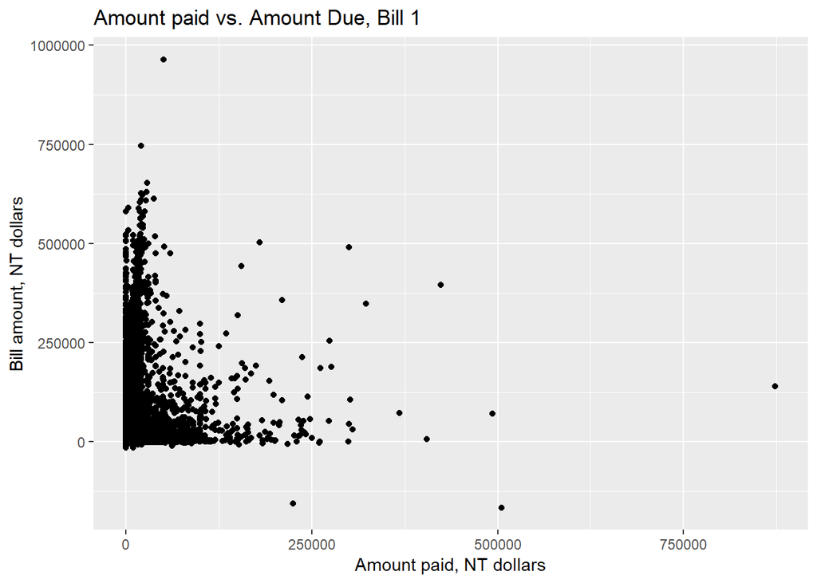

```r
#par(mfrow=c(3,2))
ggplot(data=credit)+
  geom_point(mapping=aes(x=credit$PAY_AMT1, y=credit$BILL_AMT1))+
  ggtitle('Amount paid vs. Amount Due, Bill 1')+
  ylab("Bill amount, NT dollars")+
  xlab("Amount paid, NT dollars")
```

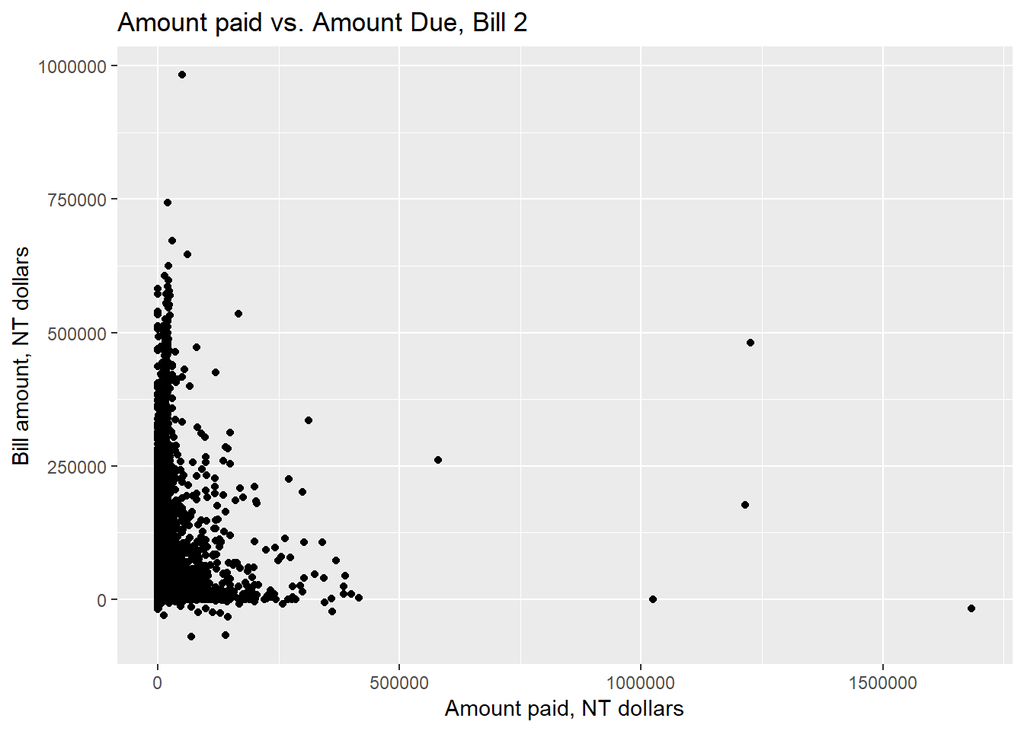

```r
ggplot(data=credit)+
  geom_point(mapping=aes(x=credit$PAY_AMT2, y=credit$BILL_AMT2))+
  ggtitle('Amount paid vs. Amount Due, Bill 2')+
  ylab("Bill amount, NT dollars")+
  xlab("Amount paid, NT dollars")
```

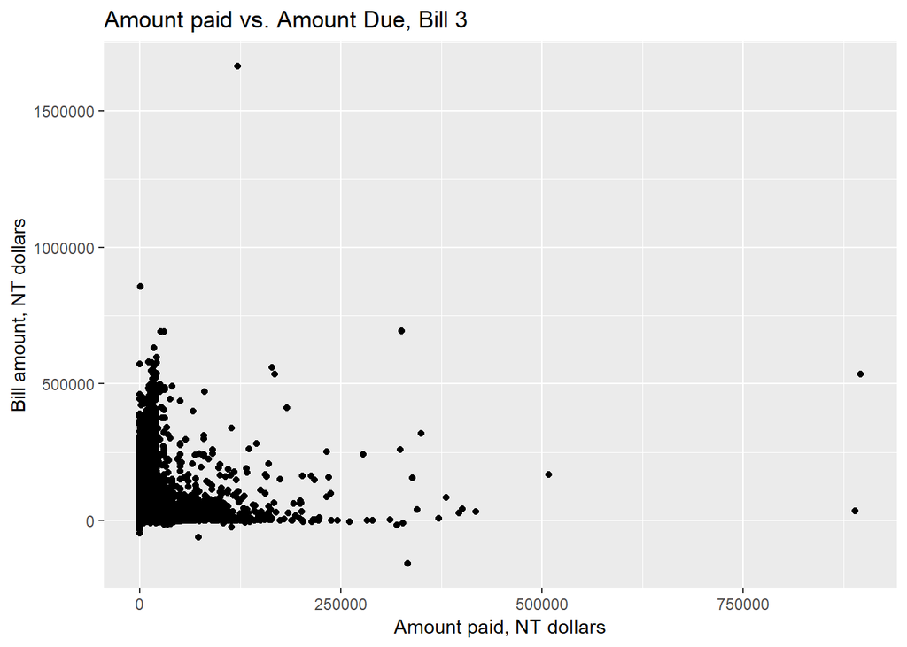

```r
ggplot(data=credit)+
  geom_point(mapping=aes(x=credit$PAY_AMT3, y=credit$BILL_AMT3))+
  ggtitle('Amount paid vs. Amount Due, Bill 3')+
  ylab("Bill amount, NT dollars")+
  xlab("Amount paid, NT dollars")
```

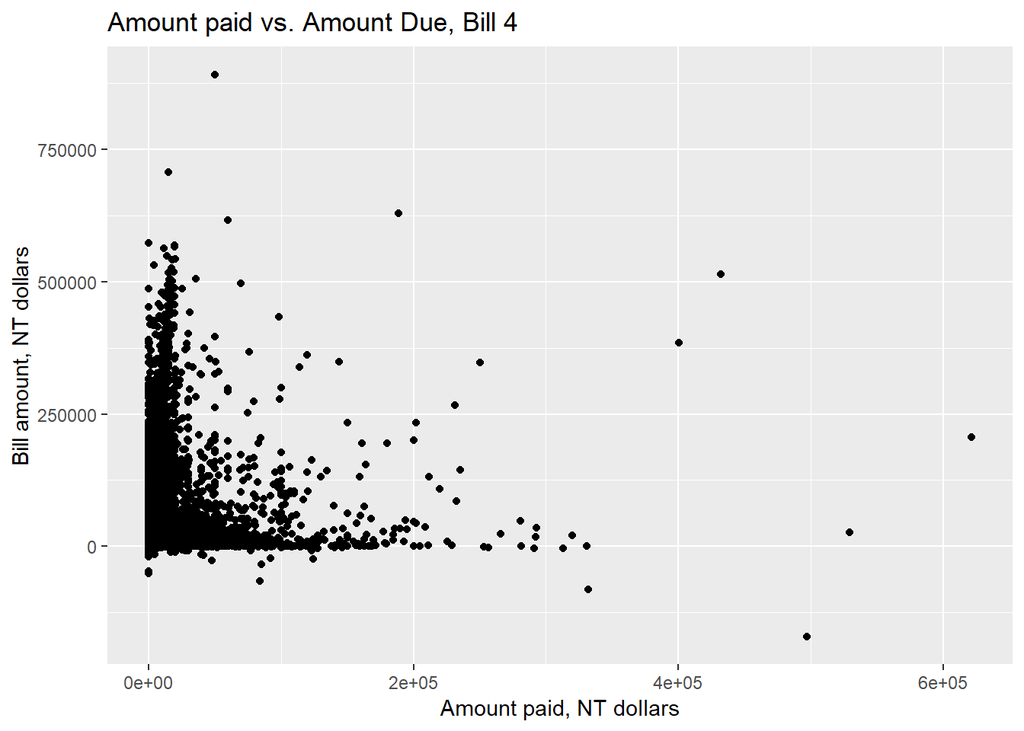

```r
ggplot(data=credit)+
  geom_point(mapping=aes(x=credit$PAY_AMT4, y=credit$BILL_AMT4))+
  ggtitle('Amount paid vs. Amount Due, Bill 4')+
  ylab("Bill amount, NT dollars")+
  xlab("Amount paid, NT dollars")
```

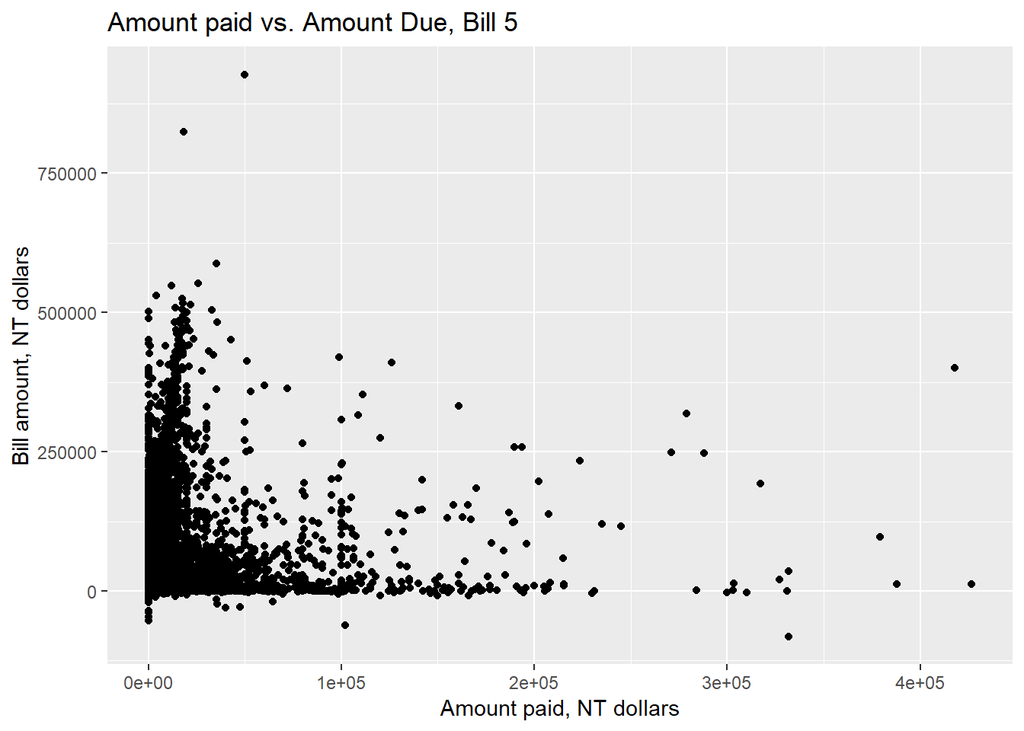

```r
ggplot(data=credit)+
  geom_point(mapping=aes(x=credit$PAY_AMT5, y=credit$BILL_AMT5))+
  ggtitle('Amount paid vs. Amount Due, Bill 5')+
  ylab("Bill amount, NT dollars")+
  xlab("Amount paid, NT dollars")
```

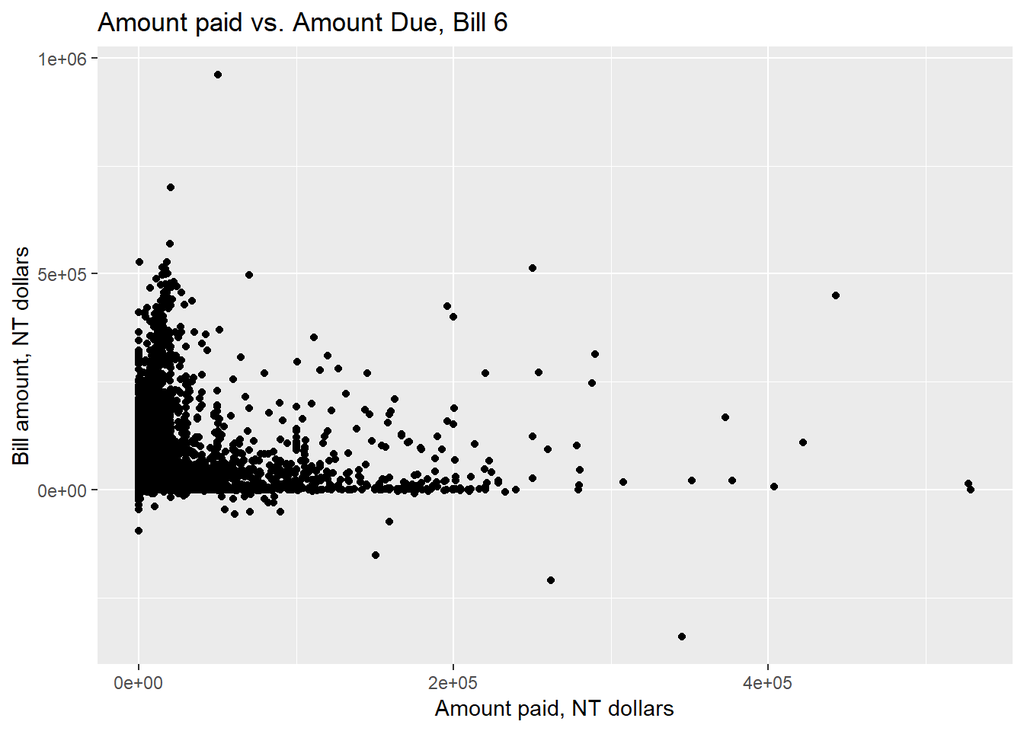

```r
ggplot(data=credit)+
  geom_point(mapping=aes(x=credit$PAY_AMT6, y=credit$BILL_AMT6))+
  ggtitle('Amount paid vs. Amount Due, Bill 6')+
  ylab("Bill amount, NT dollars")+
  xlab("Amount paid, NT dollars")
```

Now all on one plot

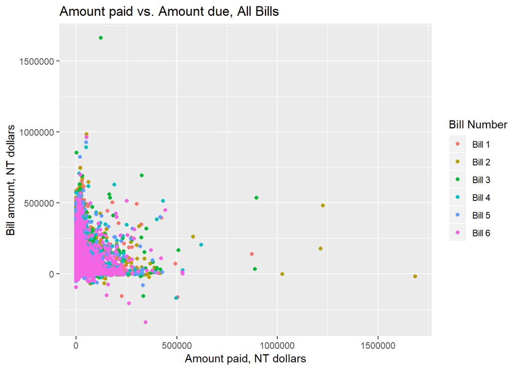

```r
#all on one plot
ggplot(data=credit)+
  geom_point(mapping=aes(x=credit$PAY_AMT1, y=credit$BILL_AMT1, col='Bill 1'))+
  geom_point(mapping=aes(x=credit$PAY_AMT2, y=credit$BILL_AMT2, col='Bill 2'))+
  geom_point(mapping=aes(x=credit$PAY_AMT3, y=credit$BILL_AMT3, col='Bill 3'))+
  geom_point(mapping=aes(x=credit$PAY_AMT4, y=credit$BILL_AMT4, col='Bill 4'))+
  geom_point(mapping=aes(x=credit$PAY_AMT5, y=credit$BILL_AMT5, col='Bill 5'))+
  geom_point(mapping=aes(x=credit$PAY_AMT6, y=credit$BILL_AMT6, col='Bill 6'))+
  xlab('Amount paid, NT dollars')+
  ylab('Bill amount, NT dollars')+
  ggtitle('Amount paid vs. Amount due, All Bills')+
  labs(color='Bill Number')
```

Is this relationship linear?

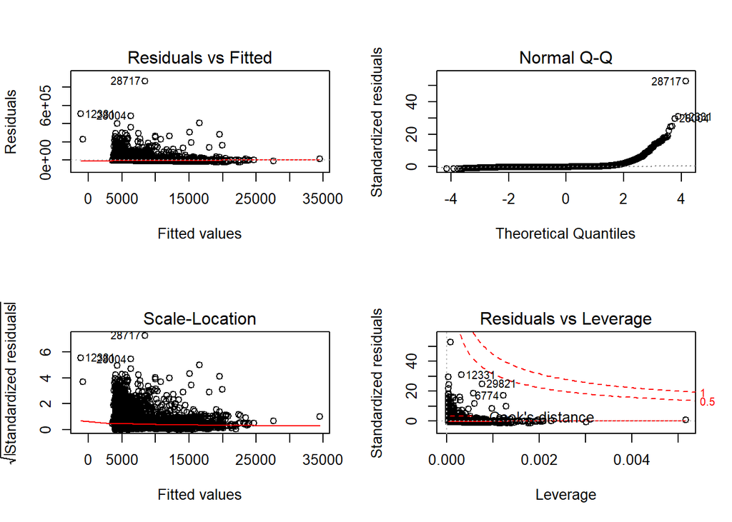

```r
par(mfrow=c(2,2))
linreg <- lm(PAY_AMT1~BILL_AMT1, data=credit)
plot(linreg)
```

```r
#No, the relationship is nonlinear. It appears to follow an inverse exponential curve.
```

Is there a pattern in bill repayment over time? It seems as though people tend to start out paying less of the bill at once, then later on in the billing cycle, they start to pay more than their current bill - to make up for last time?

What about analysis of the total amount due during the 6 months prior, and total amount paid? Who is still in-debt by the time bill 7 rolls around?

```r
credit_totals<-credit %>% group_by(ID)%>% mutate(totaldue=sum(BILL_AMT1, BILL_AMT2, BILL_AMT3, BILL_AMT4, BILL_AMT5, BILL_AMT6), totalpaid=sum(PAY_AMT1, PAY_AMT2, PAY_AMT3, PAY_AMT4, PAY_AMT5, PAY_AMT6), totaldebt=totaldue-totalpaid)
head(credit_totals)
```

```
## # A tibble: 6 x 28
## # Groups:   ID [6]
##      ID LIMIT_BAL SEX   EDUCATION MARRIAGE   AGE PAY_1 PAY_2 PAY_3 PAY_4
##   <int>     <int> <fct> <fct>     <fct>    <int> <int> <int> <int> <int>
## 1     1     20000 fema~ under gr~ married     24     2     2    -1    -1
## 2     2    120000 fema~ under gr~ single      26    -1     2     0     0
## 3     3     90000 fema~ under gr~ single      34     0     0     0     0
## 4     4     50000 fema~ under gr~ married     37     0     0     0     0
## 5     5     50000 male  under gr~ married     57    -1     0    -1     0
## 6     6     50000 male  graduate  single      37     0     0     0     0
## # ... with 18 more variables: PAY_5 <int>, PAY_6 <int>, BILL_AMT1 <int>,
## #   BILL_AMT2 <int>, BILL_AMT3 <int>, BILL_AMT4 <int>, BILL_AMT5 <int>,
## #   BILL_AMT6 <int>, PAY_AMT1 <int>, PAY_AMT2 <int>, PAY_AMT3 <int>,
## #   PAY_AMT4 <int>, PAY_AMT5 <int>, PAY_AMT6 <int>,
## #   DEFAULT_PAYMENT_NEXT_MONTH <fct>, totaldue <int>, totalpaid <int>,
## #   totaldebt <int>
```

```r
#This new dataframe shows the total due, total paid, and total debt amount at the end of the 6 month period, per person.
```

```r
summary(credit_totals)
```

```
##        ID          LIMIT_BAL           SEX                 EDUCATION
##  Min.   :    1   Min.   :  10000   female:18112   graduate      :10585
##  1st Qu.: 7501   1st Qu.:  50000   male  :11888   high school   : 4917
##  Median :15000   Median : 140000                  others        :  123
##  Mean   :15000   Mean   : 167484                  under graduate:14030
##  3rd Qu.:22500   3rd Qu.: 240000                  uneducated    :   14
##  Max.   :30000   Max.   :1000000                  unknown       :  331
##     MARRIAGE          AGE            PAY_1             PAY_2
##  married:13659   Min.   :21.00   Min.   :-2.0000   Min.   :-2.0000
##  others :  323   1st Qu.:28.00   1st Qu.:-1.0000   1st Qu.:-1.0000
##  single :15964   Median :34.00   Median : 0.0000   Median : 0.0000
##  unknown:   54   Mean   :35.49   Mean   :-0.0167   Mean   :-0.1338
##                  3rd Qu.:41.00   3rd Qu.: 0.0000   3rd Qu.: 0.0000
##                  Max.   :79.00   Max.   : 8.0000   Max.   : 8.0000
##      PAY_3             PAY_4             PAY_5             PAY_6
##  Min.   :-2.0000   Min.   :-2.0000   Min.   :-2.0000   Min.   :-2.0000
##  1st Qu.:-1.0000   1st Qu.:-1.0000   1st Qu.:-1.0000   1st Qu.:-1.0000
##  Median : 0.0000   Median : 0.0000   Median : 0.0000   Median : 0.0000
##  Mean   :-0.1662   Mean   :-0.2207   Mean   :-0.2662   Mean   :-0.2911
##  3rd Qu.: 0.0000   3rd Qu.: 0.0000   3rd Qu.: 0.0000   3rd Qu.: 0.0000
##  Max.   : 8.0000   Max.   : 8.0000   Max.   : 8.0000   Max.   : 8.0000
##    BILL_AMT1         BILL_AMT2        BILL_AMT3         BILL_AMT4
##  Min.   :-165580   Min.   :-69777   Min.   :-157264   Min.   :-170000
##  1st Qu.:   3559   1st Qu.:  2985   1st Qu.:   2666   1st Qu.:   2327
##  Median :  22382   Median : 21200   Median :  20089   Median :  19052
##  Mean   :  51223   Mean   : 49179   Mean   :  47013   Mean   :  43263
##  3rd Qu.:  67091   3rd Qu.: 64006   3rd Qu.:  60165   3rd Qu.:  54506
##  Max.   : 964511   Max.   :983931   Max.   :1664089   Max.   : 891586
##    BILL_AMT5        BILL_AMT6          PAY_AMT1         PAY_AMT2
##  Min.   :-81334   Min.   :-339603   Min.   :     0   Min.   :      0
##  1st Qu.:  1763   1st Qu.:   1256   1st Qu.:  1000   1st Qu.:    833
##  Median : 18105   Median :  17071   Median :  2100   Median :   2009
##  Mean   : 40311   Mean   :  38872   Mean   :  5664   Mean   :   5921
##  3rd Qu.: 50191   3rd Qu.:  49198   3rd Qu.:  5006   3rd Qu.:   5000
##  Max.   :927171   Max.   : 961664   Max.   :873552   Max.   :1684259
##     PAY_AMT3         PAY_AMT4         PAY_AMT5           PAY_AMT6
##  Min.   :     0   Min.   :     0   Min.   :     0.0   Min.   :     0.0
##  1st Qu.:   390   1st Qu.:   296   1st Qu.:   252.5   1st Qu.:   117.8
##  Median :  1800   Median :  1500   Median :  1500.0   Median :  1500.0
##  Mean   :  5226   Mean   :  4826   Mean   :  4799.4   Mean   :  5215.5
##  3rd Qu.:  4505   3rd Qu.:  4013   3rd Qu.:  4031.5   3rd Qu.:  4000.0
##  Max.   :896040   Max.   :621000   Max.   :426529.0   Max.   :528666.0
##  DEFAULT_PAYMENT_NEXT_MONTH    totaldue         totalpaid
##  0:23364                    Min.   :-336259   Min.   :      0
##  1: 6636                    1st Qu.:  28688   1st Qu.:   6680
##                             Median : 126311   Median :  14383
##                             Mean   : 269862   Mean   :  31651
##                             3rd Qu.: 342626   3rd Qu.:  33504
##                             Max.   :5263883   Max.   :3764066
##    totaldebt
##  Min.   :-2671514
##  1st Qu.:    4521
##  Median :  101923
##  Mean   :  238210
##  3rd Qu.:  305718
##  Max.   : 4116080
```

The summary tables show that the mean ‘total debt’ is $238,210, with a minimum of a negative amount meaning an overpayment (of $2,671,514) and a maximum debt of $4,116,080. - note these are NT dollars…convert.

```r
#Visualize total debt.
credit_totals$DEFAULT_PAYMENT_NEXT_MONTH<-as.factor(credit_totals$DEFAULT_PAYMENT_NEXT_MONTH)

#barchart(credit_totals$totaldue, credit_totals$totalpaid, credit_totals$totaldebt)
#Note - this is not how I want to visualize this...having trouble thinking of a better way
```

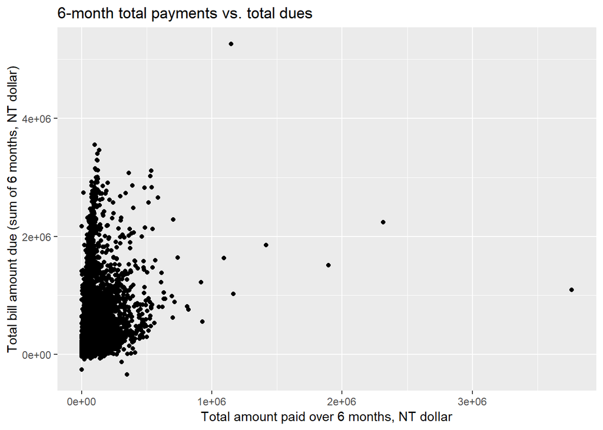

```r
ggplot(data=credit_totals)+
  geom_point(mapping=aes(x=totalpaid, y=totaldue))+
  ggtitle("6-month total payments vs. total dues")+
  ylab("Total bill amount due (sum of 6 months, NT dollar)")+
  xlab("Total amount paid over 6 months, NT dollar")
```

```r
  #col=DEFAULT_PAYMENT_NEXT_MONTH
#
#
#
#
#
#STOPPED HERE 11:29 pm 4/24/19
#
#
#need to learn how to color by default payment status.
```

log-log regression negative values - will break the model…

Can we cluster the above graph into two types of people - those who are in debt vs. those who are not?

```r
#K-means clustering

#first subset only the numeric columns of the data.
numeric<-cbind(unlist(lapply(credit, is.numeric)))
numeric<-credit[,numeric]
#head(numeric)

#Generate the elbow plot to determine best number of clusters
model <- kmeans(x=numeric, centers=2)
model$tot.withinss
```

```
## [1] 8.271888e+14
```

```r
tot_withinss<- map_dbl(1:20, function(k){
  model <- kmeans(x=numeric, centers=k)
  model$tot.withinss
})
elbow_df <- data.frame(
  k=1:20,
  tot_withinss=tot_withinss
)
```

now plot the elbow plot

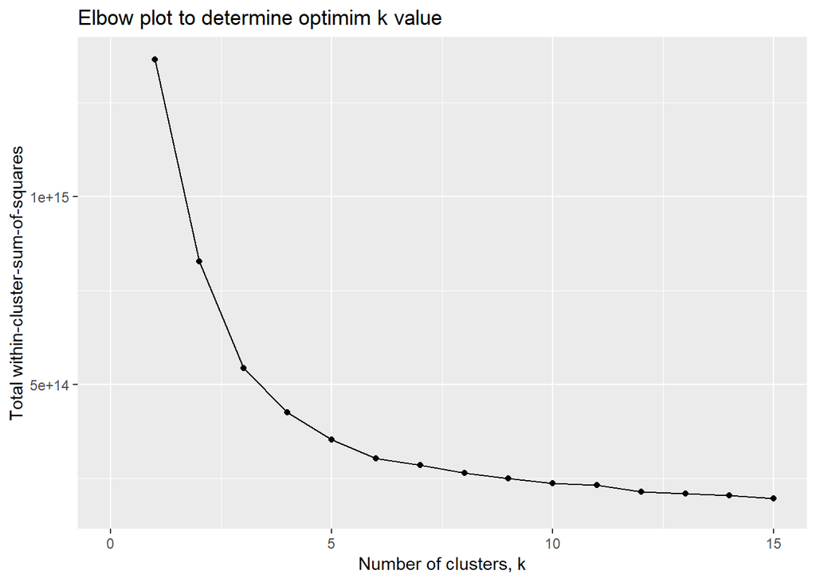

```r
ggplot(elbow_df, aes(x=k, y=tot_withinss))+
  geom_point() +
  geom_line()+
  scale_x_continuous(breaks=1:200) +
  xlim(0,15) +
  ggtitle("Elbow plot to determine optimim k value")+
  xlab("Number of clusters, k")+
  ylab("Total within-cluster-sum-of-squares")
```

Based on this plot it looks like 4 clusters is probably ideal. Run the k-means clustering with 4 clusters:

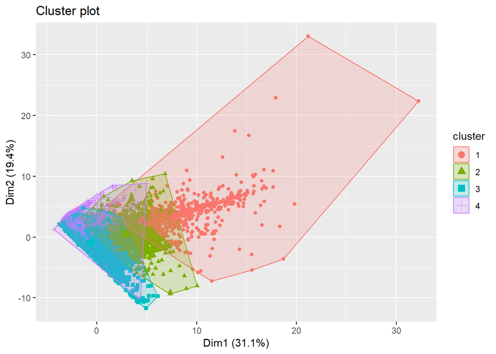

```r
#Running the cluster analysis with 2 clusters.
km <- kmeans(numeric, centers=4, iter.max=50)

#Visualizing the clusters.
fviz_cluster(km, numeric, geom=c("point"), show.clust.cent = TRUE, ellipse=TRUE,)
```

```r
#PCA analysis of these clusters.
pc<-princomp(numeric, cor=TRUE, scores=TRUE)
summary(pc)
```

```
## Importance of components:
##                           Comp.1    Comp.2    Comp.3     Comp.4     Comp.5
## Standard deviation     2.5570552 2.0159132 1.2283244 1.00817651 0.99643876
## Proportion of Variance 0.3113586 0.1935193 0.0718467 0.04840095 0.04728049
## Cumulative Proportion  0.3113586 0.5048780 0.5767247 0.62512563 0.67240611
##                            Comp.6     Comp.7     Comp.8     Comp.9
## Standard deviation     0.95847007 0.94221875 0.93473357 0.88382331
## Proportion of Variance 0.04374595 0.04227506 0.04160604 0.03719732
## Cumulative Proportion  0.71615206 0.75842711 0.80003315 0.83723047
##                           Comp.10    Comp.11    Comp.12    Comp.13
## Standard deviation     0.85598926 0.83693519 0.76905870 0.63542423
## Proportion of Variance 0.03489131 0.03335526 0.02816435 0.01922686
## Cumulative Proportion  0.87212179 0.90547705 0.93364139 0.95286825
##                           Comp.14   Comp.15     Comp.16     Comp.17
## Standard deviation     0.50981797 0.5004457 0.434329936 0.362751790
## Proportion of Variance 0.01237687 0.0119260 0.008982976 0.006266136
## Cumulative Proportion  0.96524512 0.9771711 0.986154098 0.992420234
##                            Comp.18     Comp.19    Comp.20     Comp.21
## Standard deviation     0.264525447 0.201907515 0.15879467 0.152377764
## Proportion of Variance 0.003332082 0.001941269 0.00120075 0.001105666
## Cumulative Proportion  0.995752316 0.997693584 0.99889433 1.000000000
```

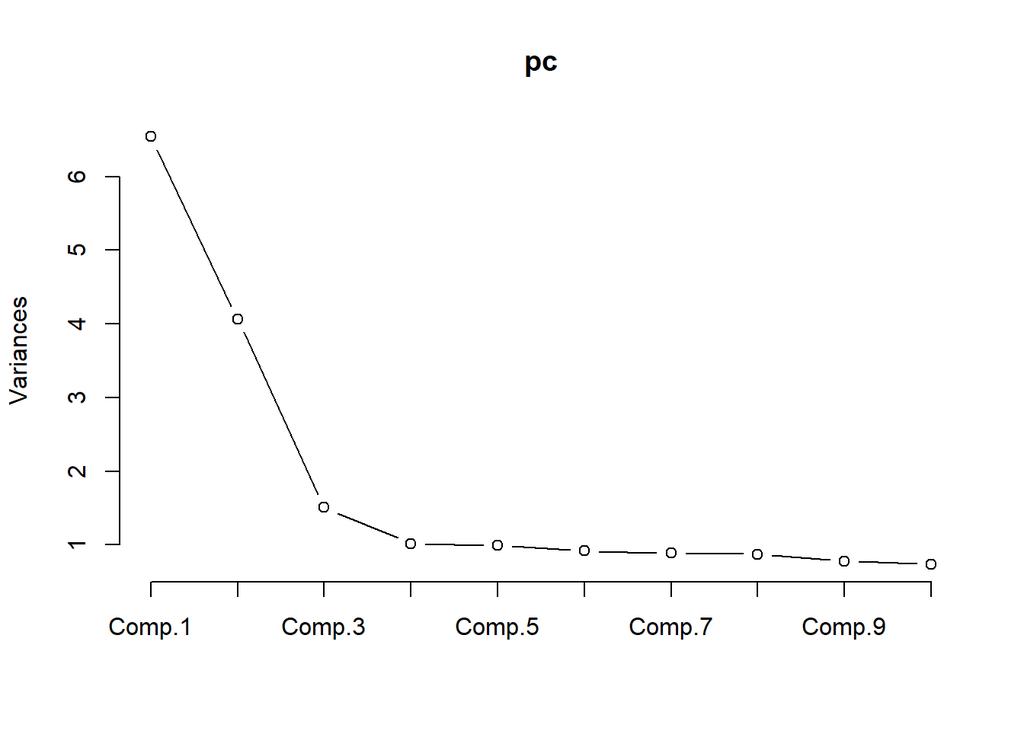

```r
plot(pc, type='lines')
```

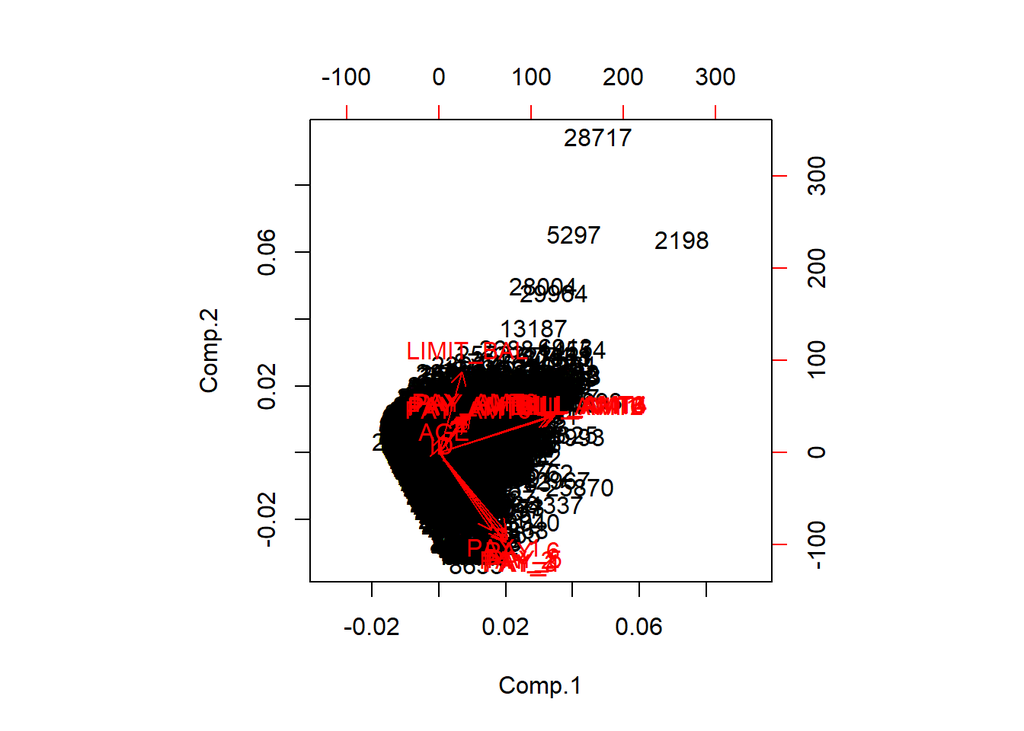

```r
biplot(pc)
```

```r
plot3d(pc$scores[,1:3])
```

Based on the results of this summary graph, it looks like by the end of the study, most people were still in debt to the bank as they owed more than they had paid.

Perhaps we can cluster the respondents into 2 groups: One who is ‘in debt’ and one who is not?